# Correction_tutorat_sport

Author

Tuteurs R

*Avant-propos* *: Ce sujet reprend la trame de l’annale et suit le même type de questions. Il sert donc de bon entraînement mais ne garantie pas les même types de questions le jour de l’examen.*

Commentaire de Valérie : Il y a des chances que l’on ajoute une question préliminaire (en tout début de devoir) demandant de parcourir le sujet et de mettre en commentaires du script (au début) si pour chaque question il y a des variables ou non à créer, lesquelles, le procédé de création à utiliser `(calcul/if/cut/casewhen)` en faisant en sorte d’indiquer des façons de faire différentes, quand c’est possible.

## Question 0

Importation avec `read.table` :

```r
sport <- read.table(file ="C:\\Users\\chris\\Documents\\M2\\TUTORAT\\sport.csv" , header=TRUE, sep=",", dec=".")
```

Chargement des packages :

```r
library(dplyr)
library(gtsummary)
theme_gtsummary_language("fr", decimal.mark = ",", big.mark=" ")
```

Il y a 2 000 observations et 17 variables :)

**ASTUCE** *(Bonus)*

Afin de voir si ton jeu de données contient des NA de façon plus visuelle, intalle le package `DataExplorer`, fait un `plot_missing` de ton jeux de données, cela te donne le % de données manquantes par variable.

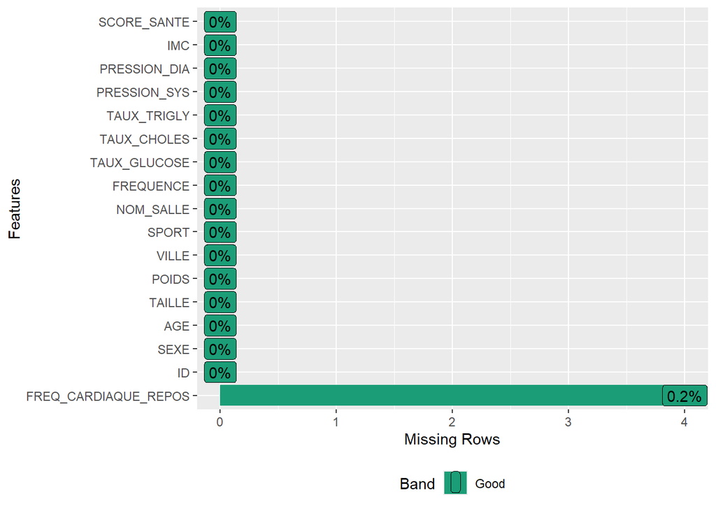

```r
library(DataExplorer)
plot_missing(sport)
```

**ATTENTION** **:** Si, dans l’énoncé, les valeurs manquantes (NA) sont codées par exemple par `"manquant"`, la fonction `plot_missing` ne les détectera pas automatiquement. Il est important de bien comprendre comment vos données sont codées avant de les analyser.

Également, pour détecter s’il existe des données aberrantes (valeurs extrêmes) dans les variables quantitatives, il est possible d’utiliser la fonction `summary()` afin d’observer l’étendue des valeurs.

Pour les variables qualitatives, on peut vérifier les modalités avec la fonction `unique()`, qui renvoie les différentes modalités de la variable.

## Question 1

Dans un premier temps il faut créer la variable catégorielle `SCORE_SANTE_CLASSE` :

```r
sport <- sport %>%
  mutate(SCORE_SANTE_CLASSE  = cut(SCORE_SANTE, breaks = seq(0, 100, by = 10), include.lowest = TRUE, right = TRUE))
```

`include.lowest` sert à inclure la valeur minimale dans la première classe de ton découpage. Même si la valeur minimal ici est 10.

`right` permet de savoir si l’on veut un intervalle fermé à droite/gauche.

Table vérif :

```r
tab_verif <- sport %>% select(SCORE_SANTE,SCORE_SANTE_CLASSE)
```

*NB : Toujous penser à comparer votre nouvelle variable avec celle d’origine* !

Il faut faire attention dans le tableau à ce que toutes les variables soient du bon type. Ici, les variables `SPORT` et `FREQUENCE` ne sont pas du bon type : elles sont de type entier (integer) au lieu d’être un facteur (factor).

Option 1 :

```r
sport$SPORT <- as.factor(sport$SPORT)
sport$FREQUENCE <- as.factor(sport$FREQUENCE)
```

Option 2 :

Vous pouvez également labeliser vos variables si vous faites un tableau, on peut directement factoriser et labeliser ou le faire à part :

```r
sport_bis <- sport %>%
  mutate(SPORT = factor(SPORT,levels = c(0, 1), labels = c("Ne va pas à la salle de sport", "Va à la salle de sport
")))
```

```r
sport_bis <-sport %>%
    mutate(FREQUENCE = factor(FREQUENCE,levels = c(0, 1,2,3), labels = c("Jamais", "Une fois par semaine
"," Entre 2 et 4 fois par semaine","5 fois ou plus par semaine.
")))
```

*NB : si vous changez les noms de vos modalités, après faudra filtrer sur ces nouveaux noms de modalités.*

On peut enfin faire le tableau !

```r
sport %>%
  select(SPORT, FREQUENCE, SCORE_SANTE,SCORE_SANTE_CLASSE ) %>%
  tbl_summary(
    statistic = list(
      all_categorical() ~ "{n} ({p}%)",
      all_continuous() ~ "{mean} ± {sd}"
    ),
    digits = all_continuous() ~ 1,
    missing = "no"
  ) %>%
  add_n() %>%
  modify_header(label ~ "**Variables**") %>% #bonus pas demandé
  modify_caption("**Tableau 1 : Résumé des informations sur la pratique sportive**") #bonus pas demandé
```

**Tableau 1 : Résumé des informations sur la pratique sportive**

| **Variables** | **N** | **N = 2 000**<sup>1</sup> |
| --- | --- | --- |
| SPORT | 2 000 |  |
| 0 |  | 789 (39%) |
| 1 |  | 1 211 (61%) |
| FREQUENCE | 2 000 |  |
| 0 |  | 789 (39%) |
| 1 |  | 367 (18%) |
| 2 |  | 604 (30%) |
| 3 |  | 240 (12%) |
| SCORE_SANTE | 2 000 | 50,3 ± 15,7 |
| SCORE_SANTE_CLASSE | 2 000 |  |
| [0,10] |  | 1 (<0,1%) |
| (10,20] |  | 29 (1,5%) |
| (20,30] |  | 180 (9,0%) |
| (30,40] |  | 350 (18%) |
| (40,50] |  | 450 (23%) |
| (50,60] |  | 412 (21%) |
| (60,70] |  | 349 (17%) |
| (70,80] |  | 172 (8,6%) |
| (80,90] |  | 54 (2,7%) |
| (90,100] |  | 3 (0,2%) |

<sup>1</sup> n (%); Moyenne ± ET

**Commentaires** :

*Bonus* *: Le titre améliore la lisibilité du tableau. Les deux étoiles au début permettent de mettre le texte en gras.*

## Question 2

Tout d’abord, il faut crée la variable `REGION`

```r
sport <- sport %>%
  mutate(REGION = case_when(
    VILLE %in% c("Lille", "Paris") ~ "NORD",
    VILLE %in% c("Strasbourg", "Lyon") ~ "EST",
    VILLE %in% c("Nantes", "Bordeaux") ~ "OUEST",
    VILLE %in% c("Marseille", "Nice", "Montpellier", "Toulouse") ~ "SUD",
    TRUE ~ NA # pour les non correspondances
  ))
```

Table vérif + verification concordance + vérification s’il a eu des non correspondances.

```r
tab_verif <- sport %>% select(REGION,VILLE)
table(sport$VILLE, sport$REGION)
```

```
              EST NORD OUEST SUD
  Bordeaux      0    0   232   0
  Lille         0  211     0   0
  Lyon        175    0     0   0
  Marseille     0    0     0 198
  Montpellier   0    0     0 213
  Nantes        0    0   196   0
  Nice          0    0     0 210
  Paris         0  187     0   0
  Strasbourg  189    0     0   0
  Toulouse      0    0     0 189
```

```r
sum(is.na(sport$REGION))
```

```
[1] 0
```

```r
Q2 <- sport %>%
  filter(SPORT == "1" & (FREQUENCE == "2" | FREQUENCE == "3") & REGION %in% c("SUD", "OUEST")) %>%
  select(SEXE, AGE, VILLE, FREQUENCE, IMC, SCORE_SANTE, REGION)
head(Q2)
```

```
  SEXE AGE       VILLE FREQUENCE  IMC SCORE_SANTE REGION
1    1  27        Nice         2 22.7        67.3    SUD
2    2  59 Montpellier         2 21.6        60.2    SUD
3    2  30 Montpellier         3 26.2        67.3    SUD
4    1  35   Marseille         2 22.7        57.1    SUD
5    1  38        Nice         2 27.0        54.8    SUD
6    2  32        Nice         2 21.8        65.7    SUD
```

Sans le `SPORT`=1 (voir NB en dessous) :

```r
Q2bis <- sport %>%
  filter((FREQUENCE == "2" | FREQUENCE == "3") & REGION %in% c("SUD", "OUEST")) %>%
  select(SEXE, AGE, VILLE, FREQUENCE, IMC, SCORE_SANTE, REGION)
head(Q2bis)
```

```
  SEXE AGE       VILLE FREQUENCE  IMC SCORE_SANTE REGION
1    1  27        Nice         2 22.7        67.3    SUD
2    2  59 Montpellier         2 21.6        60.2    SUD
3    2  30 Montpellier         3 26.2        67.3    SUD
4    1  35   Marseille         2 22.7        57.1    SUD
5    1  38        Nice         2 27.0        54.8    SUD
6    2  32        Nice         2 21.8        65.7    SUD
```

Q2 contient **529** lignes (individus).

NB : Ici `SPORT`==“1” n’était pas nécessaire car un individu avec `SPORT` ==“0” à une `FREQUENCE` == 0 par définition.

## Question 3

Tout d’abord, on crée la variable `BON_SCORE`, comme supposé dans la question, qui distingue les scores supérieurs à 70 (considérés comme « bon score ») des autres scores.

```r
sport <- sport %>%
  mutate(BON_SCORE = ifelse(SCORE_SANTE > 70, "Bon score", "Score moyen/faible"))
```

Table vérif :

```r
table_verif <- sport %>% select(BON_SCORE,SCORE_SANTE )
```

Ici il est demandé d’utiliser `tbl_summary` :

```r
sport %>%
  select(FREQUENCE, BON_SCORE) %>%
  tbl_summary(
    by = FREQUENCE,
    statistic = list(all_categorical() ~ "{p}%"),
    percent = "column",
    digits = all_categorical() ~ 1
  )
```

| **Caractéristique** | **0** N = 789<sup>1</sup> | **1** N = 367<sup>1</sup> | **2** N = 604<sup>1</sup> | **3** N = 240<sup>1</sup> |
| --- | --- | --- | --- | --- |
| BON_SCORE |  |  |  |  |
| Bon score | 0,0% | 0,8% | 14,7% | 57,1% |
| Score moyen/faible | 100,0% | 99,2% | 85,3% | 42,9% |

<sup>1</sup>

Interprétation : Parmi les individus ayant une fréquence sportive de au moins 5 fois par semaine, **57,1 %** présentent un bon score de santé, contre seulement **14,7 %** chez ceux ayant une fréquence sportive entre 2 et 4 fois par semaine.

Astuce : Pour savoir si c’est un pourcentage en ligne ou en colonne, regarde la variable que tu compares : le pourcentage se calcule par rapport au total de chaque catégorie de cette variable.

## Question 4

Tout d’abord, on filtre les individus qui vont à la salle de sport (`SPORT`=1)

```r
Q4 <- sport %>%
  filter(SPORT == "1")
```

On vérifie qu’il n’y a pas de données manquantes sur les variables cibles :

```r
Q4 %>%
  select(TAUX_GLUCOSE, TAUX_CHOLES, TAUX_TRIGLY) %>%
  summary()
```

```
  TAUX_GLUCOSE     TAUX_CHOLES     TAUX_TRIGLY
 Min.   : 65.00   Min.   :120.0   Min.   : 50.00
 1st Qu.: 79.20   1st Qu.:163.4   1st Qu.: 60.45
 Median : 86.00   Median :183.3   Median : 73.50
 Mean   : 86.49   Mean   :183.3   Mean   : 75.07
 3rd Qu.: 92.90   3rd Qu.:202.5   3rd Qu.: 87.20
 Max.   :800.90   Max.   :280.5   Max.   :153.20
```

Pas de données manquantes.

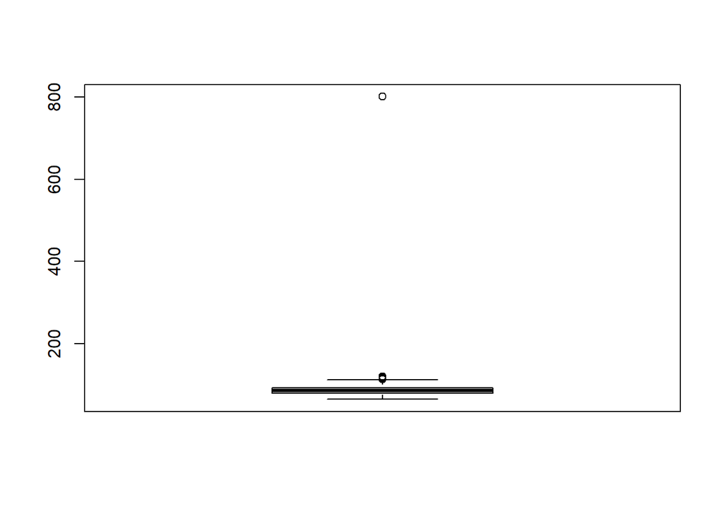

```r
boxplot(Q4$TAUX_GLUCOSE)
```

Ici, nous avons clairement une valeur aberrante à éliminer (on l’élimine directement du jeu de données `sport` ainsi que de `Q4`).

```r
sport <- sport[sport$TAUX_GLUCOSE >= 60 & sport$TAUX_GLUCOSE <= 170, ]
Q4 <- Q4[Q4$TAUX_GLUCOSE >= 60 & Q4$TAUX_GLUCOSE <= 170, ]
```

Calcul grâce à `tbl_summary`

```r
Q4 %>%
  select(TAUX_GLUCOSE, TAUX_CHOLES, TAUX_TRIGLY) %>%
  tbl_summary(
    type = everything() ~ "continuous2",
    statistic = all_continuous() ~ c("{mean}", "{sd}","{median}"),
    digits = all_continuous() ~ c(1, 1, 1)
  ) %>%
  add_n() %>% #  facultatif (non demandé)
  modify_header(label ~ "**Variable biologique**") %>% # titre facultatif
  modify_caption("**Moyenne, écart-type et médiane de la distribution des taux parmi les individus allant à la salle de sport**")
```

**Moyenne, écart-type et médiane de la distribution des taux parmi les individus allant à la salle de sport**

| **Variable biologique** | **N** | **N = 1 210** |
| --- | --- | --- |
| TAUX_GLUCOSE | 1 210 |  |
| Moyenne |  | 85,9 |
| ET |  | 9,9 |
| Médiane |  | 86,0 |
| TAUX_CHOLES | 1 210 |  |
| Moyenne |  | 183,3 |
| ET |  | 27,3 |
| Médiane |  | 183,4 |
| TAUX_TRIGLY | 1 210 |  |
| Moyenne |  | 75,1 |
| ET |  | 18,5 |
| Médiane |  | 73,5 |

ici `continuous2` permet d’afficher plusieurs lignes par variable ici on à moyenne l’écart-type et la médiane sur 3 lignes. `everything()` car le tableau ne contient que des variables continues.

## Question 5

Création de la variable `IMC_CLASSE`

```r
sport <- sport %>%
  mutate(
    IMC_CLASSE = case_when(
      IMC < 18.5 ~ "Insuffisance pondérale",
      IMC >= 18.5 & IMC <= 24.9 ~ "Normopondéral",
      IMC >= 25 & IMC <= 29.9 ~ "Surpoids",
      IMC >= 30 ~ "Obésité",
      TRUE ~ "Non défini"
    )
  )
```

Table vérif :

```r
table_verif <- sport %>%  select(IMC_CLASSE, IMC)
head(table_verif)
```

```
     IMC_CLASSE  IMC
1 Normopondéral 23.0
2 Normopondéral 20.1
3      Surpoids 25.4
4 Normopondéral 19.3
5      Surpoids 26.2
6 Normopondéral 22.7
```

On filtre sur `IMC_CLASSE` et `NOM_SALLE`:

```r
Q5 <- sport %>%
  filter(
    IMC_CLASSE %in% c("Normopondéral", "Surpoids"),
    NOM_SALLE %in% c("Fitness Park", "Basic Fit")
  )
```

On se retrouve en Q5 avec **252 lignes**.

Enfin, plusieurs façons de répondre à la question :

**Option 1**

```r
Q5bis <- Q5 %>%
  mutate(FREQUENCE_Q5 = ifelse(FREQ_CARDIAQUE_REPOS > 80, "HAUTE" , "BASSE" ))

Q5bis %>%
  select(FREQUENCE_Q5) %>%
  tbl_summary()
```

| **Caractéristique** | **N = 252**<sup>1</sup> |
| --- | --- |
| FREQUENCE_Q5 |  |
| BASSE | 250 (99%) |
| HAUTE | 2 (0,8%) |

<sup>1</sup> n (%)

**Option 2**

```r
 Q5 %>%
  summarise(
    pourcentage = sum(FREQ_CARDIAQUE_REPOS > 80, na.rm = TRUE) / sum(!is.na(FREQ_CARDIAQUE_REPOS)) * 100
  )
```

```
  pourcentage
1   0.7936508
```

**Option 3**

```r
mean(Q5$FREQ_CARDIAQUE_REPOS > 80, na.rm = TRUE) * 100
```

```
[1] 0.7936508
```

**Option 4**

```r
Q5 %>%
  filter(!is.na(FREQ_CARDIAQUE_REPOS)) %>%
  count(FREQ_CARDIAQUE_REPOS > 80) %>%
  mutate(pourcentage = n / sum(n) * 100)
```

```
  FREQ_CARDIAQUE_REPOS > 80   n pourcentage
1                     FALSE 250  99.2063492
2                      TRUE   2   0.7936508
```

**Résultat** **: ~0,8 %**

Conseil pour l’examen : Ne pas oublier de **vérifier et créer les nouvelles variables nécessaires** avec un tableau de vérification (`tab_verif`) pour comparer ancienne et nouvelle variable, et de **gérer correctement les valeurs aberrantes et les données manquantes**, surtout si elles sont codées de façon spécifique.

Bonne chance et bon courage :)